# Querying 30 Years of the UFC with SQL

### Turning a raw scrape into a clean relational database, then asking it hard questions

This notebook is a portfolio case study by **AbleVLabs**. It takes a real, messy scrape of every UFC event, fight, and fighter from ufcstats.com and does two things a data analyst is paid to do: **model the data into a clean relational schema**, and then **answer real questions with SQL**, from simple joins up to window functions.

Every query below runs against the same SQLite database that powers the live query console on the dashboard, so anything here can be re-run and explored in the browser.

## 1. The schema

The raw scrape arrives as flat, denormalized CSVs. It was normalized into four related tables with proper keys, so that fighters, events, and fights are each stored once and linked by id. This is the design an analyst reasons about before writing a single query.

```python
import sqlite3, pandas as pd
import matplotlib.pyplot as plt
plt.rcParams.update({'figure.facecolor':'#0d0d12','axes.facecolor':'#12121a',
  'savefig.facecolor':'#0d0d12','text.color':'#e8e8ef','axes.labelcolor':'#e8e8ef',
  'xtick.color':'#a9a9c0','ytick.color':'#a9a9c0','axes.edgecolor':'#2a2a3a',
  'grid.color':'#20202c','font.size':11,'axes.titlecolor':'#e8e8ef','figure.dpi':110})
CY,PU,GR,AM,RED='#22d3ee','#a855f7','#34d399','#f59e0b','#ef4444'
pd.set_option('display.max_colwidth',40)

con=sqlite3.connect('ufc.sqlite')
tables=pd.read_sql("SELECT name FROM sqlite_master WHERE type='table'", con)['name'].tolist()
for t in tables:
    n=pd.read_sql(f'SELECT COUNT(*) c FROM {t}', con)['c'][0]
    cols=pd.read_sql(f'PRAGMA table_info({t})', con)['name'].tolist()
    print(f'{t:12s} {n:6d} rows   ({", ".join(cols)})')
```

```
events          789 rows   (event_id, name, date, city, country)
fighters       4623 rows   (fighter_id, name, height_in, reach_in, weight_lbs, stance, dob)
bouts          8885 rows   (bout_id, event_id, fighter1_id, fighter2_id, winner_id, result_type, weight_class, title_bout, method, method_group, round, time, end_secs, referee, duration_secs)
fight_stats   17726 rows   (bout_id, fighter_id, kd, sig_str_landed, sig_str_att, total_str_landed, td_landed, td_att, sub_att, reversals, ctrl_secs)
```

The relationships in one line: **bouts** is the hub. Each bout points to an **event** and to two **fighters**, names a **winner**, and has matching rows in **fight_stats**. That star shape is what makes the joins below natural.

## 2. Who has the most UFC wins?

**Technique: JOIN + GROUP BY + COUNT.** Join every bout to its winner, then count wins per fighter. The simplest bread-and-butter query, and the foundation everything else builds on.

```python
sql = """\
SELECT f.name, COUNT(*) AS wins
FROM bouts b
JOIN fighters f ON f.fighter_id = b.winner_id
GROUP BY f.fighter_id
ORDER BY wins DESC
LIMIT 10;
"""
df = pd.read_sql(sql, con)
df
```

|  | name | wins |
| --- | --- | --- |
| 0 | Jim Miller | 28 |
| 1 | Neil Magny | 25 |
| 2 | Charles Oliveira | 25 |
| 3 | Max Holloway | 24 |
| 4 | Donald Cerrone | 23 |
| 5 | Andrei Arlovski | 23 |
| 6 | Jon Jones | 22 |
| 7 | Dustin Poirier | 22 |
| 8 | Demian Maia | 22 |
| 9 | Rafael Dos Anjos | 21 |

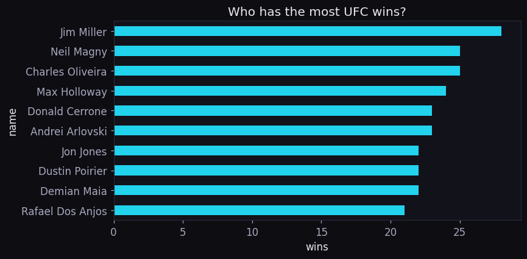

```python
ax=df.iloc[::-1].plot.barh(x='name',y='wins',color=CY,legend=False,figsize=(8,4))
ax.set_title("Who has the most UFC wins?"); ax.set_xlabel('wins'); plt.tight_layout(); plt.show()
```

## 3. Which fighters finish, instead of coasting to a decision?

**Technique: CTE + CASE + ratio.** A CTE counts each fighter's wins and how many were finishes (KO or submission), then the outer query turns that into a finish percentage. CASE inside SUM is the classic way to count a condition.

```python
sql = """\
WITH w AS (
  SELECT winner_id AS fid,
         COUNT(*) AS wins,
         SUM(CASE WHEN method_group IN ('KO/TKO','Submission') THEN 1 ELSE 0 END) AS finishes
  FROM bouts
  WHERE winner_id IS NOT NULL
  GROUP BY winner_id
)
SELECT f.name, w.wins, w.finishes,
       ROUND(100.0 * w.finishes / w.wins, 1) AS finish_pct
FROM w
JOIN fighters f ON f.fighter_id = w.fid
WHERE w.wins >= 15
ORDER BY finish_pct DESC, wins DESC
LIMIT 10;
"""
df = pd.read_sql(sql, con)
df
```

|  | name | wins | finishes | finish_pct |
| --- | --- | --- | --- | --- |
| 0 | Vitor Belfort | 15 | 14 | 93.3 |
| 1 | Matt Brown | 17 | 15 | 88.2 |
| 2 | Vicente Luque | 17 | 15 | 88.2 |
| 3 | Joe Lauzon | 15 | 13 | 86.7 |
| 4 | Charles Oliveira | 25 | 21 | 84.0 |
| 5 | Anderson Silva | 17 | 14 | 82.4 |
| 6 | Frank Mir | 16 | 13 | 81.3 |
| 7 | Glover Teixeira | 16 | 13 | 81.3 |
| 8 | Derrick Lewis | 20 | 16 | 80.0 |
| 9 | Drew Dober | 15 | 12 | 80.0 |

## 4. Do heavier fighters really knock people out more?

**Technique: Conditional aggregation (pivot with CASE).** Group bouts by weight class and, in one pass, compute the share ending by KO, submission, and decision. This pivots a category column into three metric columns.

```python
sql = """\
SELECT weight_class,
       COUNT(*) AS bouts,
       ROUND(100.0*SUM(method_group='KO/TKO')  /COUNT(*),1) AS ko_pct,
       ROUND(100.0*SUM(method_group='Submission')/COUNT(*),1) AS sub_pct,
       ROUND(100.0*SUM(method_group='Decision') /COUNT(*),1) AS dec_pct
FROM bouts
WHERE weight_class IN ('Flyweight','Bantamweight','Featherweight','Lightweight',
      'Welterweight','Middleweight','Light Heavyweight','Heavyweight')
GROUP BY weight_class
ORDER BY bouts DESC;
"""
df = pd.read_sql(sql, con)
df
```

|  | weight_class | bouts | ko_pct | sub_pct | dec_pct |
| --- | --- | --- | --- | --- | --- |
| 0 | Lightweight | 1465 | 30.0 | 21.7 | 47.2 |
| 1 | Welterweight | 1399 | 33.5 | 18.2 | 47.1 |
| 2 | Middleweight | 1154 | 38.0 | 21.1 | 39.3 |
| 3 | Featherweight | 871 | 29.5 | 16.5 | 52.9 |
| 4 | Bantamweight | 791 | 26.0 | 19.5 | 52.5 |
| 5 | Heavyweight | 768 | 51.3 | 14.2 | 32.7 |
| 6 | Light Heavyweight | 765 | 45.0 | 17.0 | 35.9 |
| 7 | Flyweight | 428 | 23.6 | 21.5 | 53.7 |

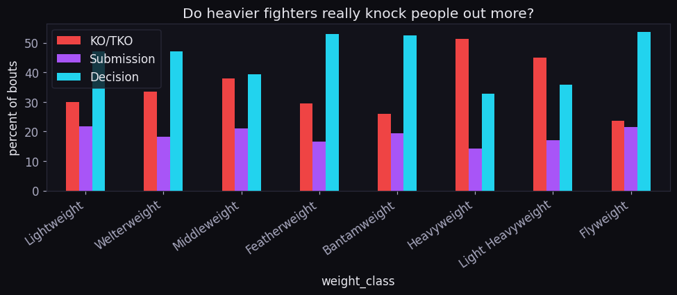

```python
ax=df.set_index('weight_class')[['ko_pct', 'sub_pct', 'dec_pct']].plot.bar(color=[RED,PU,CY],figsize=(9,4))
ax.set_title("Do heavier fighters really knock people out more?"); ax.set_ylabel('percent of bouts'); ax.legend(['KO/TKO','Submission','Decision'],facecolor='#12121a',edgecolor='#2a2a3a',labelcolor='#e8e8ef'); plt.xticks(rotation=35,ha='right'); plt.tight_layout(); plt.show()
```

## 5. The longest win streaks in UFC history

**Technique: Window functions (gaps and islands).** The showpiece. Each bout is unpivoted to one row per fighter with a win flag, then two ROW_NUMBER() windows are subtracted so consecutive wins share an island id. Counting each island gives the streak length.

```python
sql = """\
WITH per_fighter AS (
  SELECT b.bout_id, b.fighter1_id AS fid, e.date AS d,
         (b.winner_id = b.fighter1_id) AS won
  FROM bouts b JOIN events e ON e.event_id = b.event_id
  WHERE b.result_type = 'Win'
  UNION ALL
  SELECT b.bout_id, b.fighter2_id, e.date,
         (b.winner_id = b.fighter2_id)
  FROM bouts b JOIN events e ON e.event_id = b.event_id
  WHERE b.result_type = 'Win'
),
islands AS (
  SELECT fid, won,
         ROW_NUMBER() OVER (PARTITION BY fid          ORDER BY d, bout_id)
       - ROW_NUMBER() OVER (PARTITION BY fid, won     ORDER BY d, bout_id) AS grp
  FROM per_fighter
)
SELECT f.name, COUNT(*) AS win_streak
FROM islands
JOIN fighters f ON f.fighter_id = islands.fid
WHERE won = 1
GROUP BY fid, grp
ORDER BY win_streak DESC
LIMIT 10;
"""
df = pd.read_sql(sql, con)
df
```

|  | name | win_streak |
| --- | --- | --- |
| 0 | Jon Jones | 19 |
| 1 | Islam Makhachev | 17 |
| 2 | Anderson Silva | 16 |
| 3 | Kamaru Usman | 15 |
| 4 | Merab Dvalishvili | 14 |
| 5 | Demetrious Johnson | 13 |
| 6 | Georges St-Pierre | 13 |
| 7 | Khabib Nurmagomedov | 13 |
| 8 | Max Holloway | 13 |
| 9 | Alexander Volkanovski | 12 |

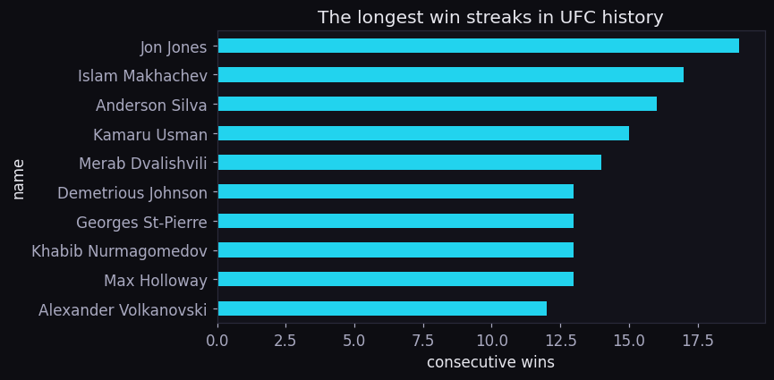

```python
ax=df.iloc[::-1].plot.barh(x='name',y='win_streak',color=CY,legend=False,figsize=(8,4))
ax.set_title("The longest win streaks in UFC history"); ax.set_xlabel('consecutive wins'); plt.tight_layout(); plt.show()
```

## 6. The fastest finishes ever recorded

**Technique: Multi-table JOIN + derived opponent.** Join each bout to its winner and event, then join again to look up the loser (the other corner) with a CASE. Ordering by elapsed seconds surfaces the quickest stoppages.

```python
sql = """\
SELECT f.name AS winner,
       l.name AS loser,
       b.method, b.time,
       ev.name AS event, ev.date
FROM bouts b
JOIN fighters f  ON f.fighter_id = b.winner_id
JOIN fighters l  ON l.fighter_id = CASE WHEN b.winner_id = b.fighter1_id
                                        THEN b.fighter2_id ELSE b.fighter1_id END
JOIN events   ev ON ev.event_id = b.event_id
WHERE b.method_group IN ('KO/TKO','Submission')
  AND b.round = 1 AND b.end_secs > 0
ORDER BY b.end_secs ASC
LIMIT 10;
"""
df = pd.read_sql(sql, con)
df
```

|  | winner | loser | method | time | event | date |
| --- | --- | --- | --- | --- | --- | --- |
| 0 | Jorge Masvidal | Ben Askren | KO/TKO | 0:05 | UFC 239: Jones vs. Santos | 2019-07-06 |
| 1 | Duane Ludwig | Jonathan Goulet | KO/TKO | 0:06 | UFC Fight Night 3 | 2006-01-16 |
| 2 | Chan Sung Jung | Mark Hominick | KO/TKO | 0:07 | UFC 140: Jones vs Machida | 2011-12-10 |
| 3 | Ryan Jimmo | Anthony Perosh | KO/TKO | 0:07 | UFC 149: Faber vs Barao | 2012-07-21 |
| 4 | Terrance McKinney | Matt Frevola | KO/TKO | 0:07 | UFC 263: Adesanya vs. Vettori 2 | 2021-06-12 |
| 5 | Todd Duffee | Tim Hague | KO/TKO | 0:07 | UFC 102: Couture vs Nogueira | 2009-08-29 |
| 6 | Abdul Rakhman Yakhyaev | Julius Walker | KO/TKO | 0:08 | UFC Fight Night: Fiziev vs. Torres | 2026-06-27 |
| 7 | Don Frye | Thomas Ramirez | KO/TKO | 0:08 | UFC 8: David vs Goliath | 1996-02-16 |
| 8 | James Irvin | Houston Alexander | KO/TKO | 0:08 | UFC Fight Night: Florian vs Lauzon | 2008-04-02 |
| 9 | Leon Edwards | Seth Baczynski | KO/TKO | 0:08 | UFC Fight Night: Gonzaga vs Cro Cop 2 | 2015-04-11 |

## 7. Does a longer reach actually win fights?

**Technique: Self-join + conditional aggregate.** Join the bout to both fighters' tale-of-the-tape, keep bouts where reaches differ, and measure how often the longer-reach fighter won. A data-driven myth check.

```python
sql = """\
WITH r AS (
  SELECT b.winner_id, b.fighter1_id, b.fighter2_id,
         f1.reach_in AS reach1, f2.reach_in AS reach2
  FROM bouts b
  JOIN fighters f1 ON f1.fighter_id = b.fighter1_id
  JOIN fighters f2 ON f2.fighter_id = b.fighter2_id
  WHERE b.result_type = 'Win'
    AND f1.reach_in IS NOT NULL AND f2.reach_in IS NOT NULL
    AND f1.reach_in <> f2.reach_in
)
SELECT COUNT(*) AS decided_bouts,
       ROUND(100.0*SUM(CASE WHEN (reach1>reach2 AND winner_id=fighter1_id)
                              OR (reach2>reach1 AND winner_id=fighter2_id)
                            THEN 1 ELSE 0 END)/COUNT(*),1) AS longer_reach_win_pct
FROM r;
"""
df = pd.read_sql(sql, con)
df
```

|  | decided_bouts | longer_reach_win_pct |
| --- | --- | --- |
| 0 | 6576 | 52.1 |

## 8. How the UFC exploded: bouts per year

**Technique: Date bucketing + GROUP BY.** Pull the year out of each event date and count bouts. A time series that tells the story of the sport growing from a curiosity in 1994 to hundreds of fights a year.

```python
sql = """\
SELECT strftime('%Y', e.date) AS year,
       COUNT(*) AS bouts
FROM bouts b
JOIN events e ON e.event_id = b.event_id
WHERE e.date IS NOT NULL
GROUP BY year
ORDER BY year;
"""
df = pd.read_sql(sql, con)
df
```

|  | year | bouts |
| --- | --- | --- |
| 0 | 1994 | 31 |
| 1 | 1995 | 40 |
| 2 | 1996 | 43 |
| 3 | 1997 | 41 |
| 4 | 1998 | 25 |
| 5 | 1999 | 44 |
| 6 | 2000 | 43 |
| 7 | 2001 | 40 |
| 8 | 2002 | 53 |
| 9 | 2003 | 41 |
| 10 | 2004 | 39 |
| 11 | 2005 | 80 |
| 12 | 2006 | 158 |
| 13 | 2007 | 171 |
| 14 | 2008 | 201 |
| 15 | 2009 | 215 |
| 16 | 2010 | 253 |
| 17 | 2011 | 300 |
| 18 | 2012 | 341 |
| 19 | 2013 | 386 |
| 20 | 2014 | 503 |
| 21 | 2015 | 473 |
| 22 | 2016 | 493 |
| 23 | 2017 | 457 |
| 24 | 2018 | 474 |
| 25 | 2019 | 516 |
| 26 | 2020 | 456 |
| 27 | 2021 | 509 |
| 28 | 2022 | 511 |
| 29 | 2023 | 520 |
| 30 | 2024 | 517 |
| 31 | 2025 | 520 |
| 32 | 2026 | 364 |

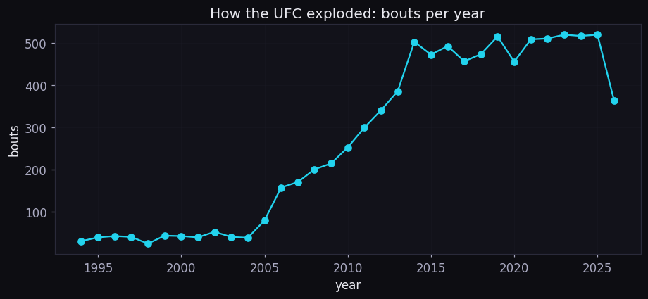

```python
d=df.copy(); d['year']=d['year'].astype(int)
ax=d.plot(x='year',y='bouts',marker='o',color=CY,legend=False,figsize=(8.5,4))
ax.set_title("How the UFC exploded: bouts per year"); ax.set_ylabel('bouts'); ax.grid(True,alpha=.25); plt.tight_layout(); plt.show()
```

## 9. The grinders: most octagon control time

**Technique: JOIN to stats + SUM + HAVING.** Sum control-time seconds from the per-fight stats table for each fighter, filtering to those with a real sample of fights. HAVING filters on the aggregate, which WHERE cannot do.

```python
sql = """\
SELECT f.name,
       ROUND(SUM(s.ctrl_secs)/60.0) AS control_minutes,
       COUNT(*) AS fights
FROM fight_stats s
JOIN fighters f ON f.fighter_id = s.fighter_id
GROUP BY s.fighter_id
HAVING fights >= 12
ORDER BY control_minutes DESC
LIMIT 10;
"""
df = pd.read_sql(sql, con)
df
```

|  | name | control_minutes | fights |
| --- | --- | --- | --- |
| 0 | Georges St-Pierre | 162.0 | 22 |
| 1 | Clay Guida | 156.0 | 37 |
| 2 | Demian Maia | 155.0 | 33 |
| 3 | Kamaru Usman | 147.0 | 20 |
| 4 | Rafael Dos Anjos | 137.0 | 36 |
| 5 | Darren Elkins | 129.0 | 31 |
| 6 | Jon Fitch | 128.0 | 18 |
| 7 | Randy Couture | 127.0 | 24 |
| 8 | Colby Covington | 125.0 | 17 |
| 9 | Valentina Shevchenko | 122.0 | 20 |

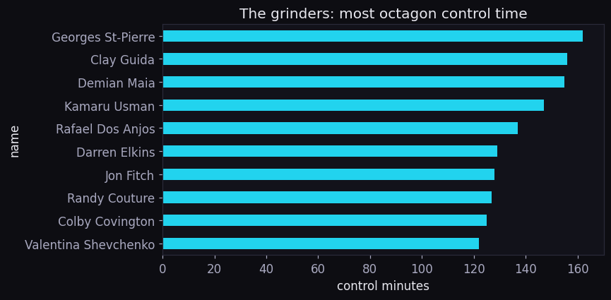

```python
ax=df.iloc[::-1].plot.barh(x='name',y='control_minutes',color=CY,legend=False,figsize=(8,4))
ax.set_title("The grinders: most octagon control time"); ax.set_xlabel('control minutes'); plt.tight_layout(); plt.show()
```

## Takeaways

- **Modeling first.** A flat scrape became four linked tables. That single design choice is what turns a pile of CSV rows into something you can ask questions of.
- **The right tool per question.** Counting wins is a join and a group by. Finish rate needs a CASE. Streaks need window functions. Reach needs a self-join. Matching the SQL pattern to the question is the core skill.
- **The findings are real and recognizable.** The most UFC wins, the longest streaks, the fastest finishes, and the fact that a reach advantage wins only about half the time all come straight out of the data, not out of assumptions.

The same database is live on the dashboard, where anyone can run these queries or write their own.

*Data: ufcstats.com (scraped, public). Schema design, queries, and visuals by AbleVLabs.*

```python
con.close()
```